# Assignment 9

Jon Brauer & Tyeisha Fordham

2022-10-01

### Assignment 9 Objectives

#### The purpose of this ninth assignment is to help you use R to complete some of the SPSS Exercises from the end of Chapter 9 in Bachman, Paternoster, & Wilson’s [Statistics for Criminology & Criminal Justice, 5th Ed](https://edge.sagepub.com/bachmansccj5e).

In the last assignment, you learned how to conduct a one-sample *z* or *t* hypothesis test of the difference between a sample and population mean and then, given the test results and the null hypothesis, to make an appropriate inference about the population mean by either rejecting or failing to reject the null hypothesis. In this assignment, you will learn how to make population inferences about the relationship between two categorical variables by conducting a chi-squared test of independence on a sample contingency table (crosstab).

#### By the end of assignment #9, you should…

- recognize you can manually build a simple tibble row-by-row using tidyverse’s `tibble::tribble()`
- recognize you can use `round()` to specify number of decimals on numeric values
- recognize you can modify a `gt()` table to add or remove the decimals in specific columns or rows with `fmt_number()`
- be able to conduct a chi-squared test of independence using `sjPlot::sjtab()` or `chisq.test()` and interpret results
  - know how to specify different measures of association with `statistics=` using `sjPlot::sjtab()` and interpret them appropriately.
  - know how to generate observed and expected frequencies by assigning results of `chisq.test()` to an object (e.g., `chisq`) and then calling elements from object (e.g., `chisq$observed` or `chisq$expected`)

### Assumptions & Ground Rules

#### We are building on objectives from Assignments 1-8. By the start of this assignment, you should already know how to:

#### Basic R/RStudio skills

- create an R Markdown (RMD) file and add/modify text, level headers, and R code chunks within it
- knit your RMD document into an HTML file that you can then save and submit for course credit
- install/load R packages and use hashtags (“#”) to comment out sections of R code so it does not run
- recognize when a function is being called from a specific package using a double colon with the `package::function()` format
- read in an SPSS data file in an R code chunk using `haven::read_spss()` and assign it to an R object using an assignment (`<-`) operator
- use the `$` symbol to call a specific element (e.g., a variable, row, or column) within an object (e.g., dataframe or tibble), such as with the format `dataobject$varname`
- use a tidyverse `%>%` pipe operator to perform a sequence of actions
- recognize the R operator `!=` as “not equal to”
- turn off or change scientific notation in R, such as `options(scipen=999, digits = 3)`
- create a list or vector and assign to object, such as `listname <- c(item1, item2)`
- recognize that use `lapply()` to create a list of objects, which can help you avoid cluttering the R Environment with objects
- recognize that you can create your own R functions (e.g., our `funxtoz()` function) - and that doing so is recommended for duplicate tasks to avoid copy-and-paste errors

#### Reproducibility

- use `here()` for a simple and reproducible self-referential file directory method
- Use `groundhog.library()` as an optional but recommended reproducible alternative to `library()` for loading packages
- improve reproducibility of randomization tasks in R by setting the random number generator seed using `set.seed()`
- know that you can share examples or troubleshoot code in a reproducible way by using built-in datasets like `mtcars` that are universally available to R users

#### Data viewing & wrangling

- use the base R `head()` function to quickly view the first few rows of data
- use the base R `tail()` function to quickly view the last few rows of data
- use the `glimpse()` function to quickly view all columns (variables) in your data
- use `sjPlot::view_df()` to quickly browse variables in a data file
- use `attr()` to identify variable and attribute value labels
- recognize when missing values are coded as `NA` for variables in your data file
- remove missing observations from a variable in R when appropriate using `filter(!is.na(var))`
- change a numeric variable to a factor (e.g., nominal or ordinal) variable with `haven::as_factor()`
- drop an unused factor level (e.g., missing “Don’t know” label) on a variable using `data %>% droplevels(data$variable)`
- select and recode variables using dplyr’s `select()`, `mutate()`, and `if_else()` functions
- convert raw column (variable) values into standardized z-score values using `mutate()`
- select random sample from data without or with replacement using `dplyr::sample_n()`
- select data with conditions using `dplyr::filter()` and `%in%` operator
- simulate data from normal, truncated normal, or uniform probability distributions using `rnorm()`, `truncnorm::rtruncnorm()`, or `runif()`
- draw random samples from data in R
  - draw one random sample with `dplyr::slice_sample()`
  - draw multiple (“replicate”) random samples with `infer::rep_slice_sample()`

#### Descriptive data analysis

- use `summarytools::dfsummary()` to quickly describe one or more variables in a data file
- create frequency tables with `sjmisc:frq()` and `summarytools::freq()` functions
- sort frequency distributions (lowest to highest/highest to lowest) with `summarytools::freq()`
- calculate measures of central tendency for a frequency distribution
  - calculate central tendency using base R functions `mean()` and `median()` (e.g., `mean(data$variable`))
  - calculate central tendency and other basic descriptive statistics for specific variables in a dataset using `summarytools::descr()` and `psych::describe()` functions
- calculate measures of dispersion for a variable distribution
  - calculate dispersion measures by hand from frequency tables you generate in R
  - calculate some measures of dispersion (e.g., standard deviation) directly in R (e.g., with `sjmisc:frq()` or `summarytools::descr()`)
- recognize and read the basic elements of a contingency table (aka crosstab)
  - place IV in columns and DV in rows of a crosstab
  - recognize column/row marginals and their overlap with univariate frequency distributions
  - calculate marginal, conditional, and joint (frequentist) probabilities
  - compare column percentages (when an IV is in columns of a crosstab)
- generate and modify a contingency table (crosstab) in R with `dplyr::select()` & `sjPlot::sjtab(depvar, indepvar)` or with `crosstable(depvar, by=indepvar)`

#### Data visualization & aesthetics

- improve some knitted tables by piping a function’s results to `gt()` (e.g., `head(data) %>% gt()`)
  - modify elements of a `gt()` table, such as adding titles/subtitles with Markdown-formatted (e.g., `**bold**` or `*italicized*`) fonts
- create basic graphs using ggplot2’s `ggplot()` function
  - generate simple bar charts and histograms to visualize shape and central tendency of a frequency distribution
  - generate boxplots using base R `boxplot()` and `ggplot()` to visualize dispersion in a data distribution
- modify elements of a ggplot object
  - change outline and fill colors in a ggplot geometric object (e.g., `geom_boxplot()`) by adding `fill=` and `color=` followed by specific color names (e.g., “orange”) or hexidecimal codes (e.g., “#990000” for crimson; “#EDEBEB” for cream)
  - add or change a preset theme (e.g., `+ theme_minimal()`) to a ggplot object to conveniently modify certain plot elements (e.g., white background color)
  - select colors from a colorblind accessible palette (e.g., using `viridisLite::viridis()`) and specify them for the outline and fill colors in a ggplot geometric object (e.g., `geom_boxplot()`)
  - add a title (and subtitle or caption) to a ggplot object by adding a label with the `labs()` function (e.g., `+ labs(title = "My Title")`)
- be able to combine multiple `ggplot()` plots into a single figure using “patchwork” package
  - know how to customize plot layout and add title to patchwork figure
  - recognize that one can write a custom function to repeatedly generate similar plots before combining them with patchwork
  - recognize you can use `patchwork::wrap_plots()` to quickly combine ggplot objects contained in a list
- recognize that one can plot means and confidence intervals using `ggplot() + geom_point() + geom_errorbars`
- recognize that one can add elements like vertical lines (`+ geom_vline()`), arrows (`+ geom_segment`), or text (`+ annotate()`) elements to a `ggplot()` object

#### Hypothesis testing & statistical inference

- conduct and interpret a null hypothesis significance test
  - specify null (test) hypothesis & identify contrasting alternative hypothesis (or hypotheses)
  - set an alpha or significance level (e.g., as risk tolerance or false positive error control rate)
  - calculate a test statistic and corresponding *p*-value
  - compare a test *p*-value to alpha level and then determine whether the evidence is sufficient to reject the null hypothesis or should result in a failure to reject the null hypothesis
- conduct a bimomial hypothesis test in R with `rstatix::binom_test()`
- generate and interpret confidence intervals to quantify uncertainty caused by sampling variability
  - identify *t* or *z* critical values associated with a two-tailed confidence level using `qt()` or `qnorm()`
  - estimate the standard error of a sample mean or proportion in R
  - estimate a two-tailed confidence interval around a sample mean or proportion in R
  - properly interpret and avoid common misinterpretations of confidence intervals
- be able to conduct a one-sample *z* or *t* hypothesis test of the difference between a sample and assumed population mean in R and interpret results
  - be able to conduct a one-sample test using the base R `t.test()` function
  - be able to manually calculate a *z* or *t* test statistic by typing formula in R
  - be able to conduct a one-sample test using `infer::t_test()`
  - know how to use `infer::visualize()` to visualize where your sample statistic would fall in the sampling distribution associated with your null hypothesis

**If you do not recall how to do these things, review Assignments 1-8.**

Additionally, you should have read the assigned book chapter and reviewed the SPSS questions that correspond to this assignment, and you should have completed any other course materials (e.g., videos; readings) assigned for this week before attempting this R assignment. In particular, for this week, I assume you understand:

- contingency tables or crosstabs
  - joint frequency distribution
  - column marginal or column frequency
  - row marginal or row frequency
  - how to compare percentage differences (across IV and within DV categories)
- chi-squared test of independence
  - observed frequency
  - expected frequency
  - how to calculate with the definitional and computational formulas
- measures of association
  - positive and negative relationships
  - how to calculate and when to use phi-coefficient, contingency coefficient, Cramer’s *V* (e.g., table size, levels of measurement)
  - how to calculate and when to use proportionate reduction in error (PRE) measures of association including lambda, Goodman & Kruskal’s gamma, or Yule’s Q (e.g., table size, levels of measurement)

As noted previously, for this and all future assignments, you MUST type all commands in by hand. *Do not copy & paste except for troubleshooting purposes (i.e., if you cannot figure out what you mistyped).*

### Understanding “statistical independence”

#### Goal: Understand the null hypothesis of statistical independence and visualize chi-squared test of independence

A few assignments back (#6), you learned how to describe the association between two categorical variables by creating and interpreting a contingency table or crosstab. In this assignment, you will learn how to make an inference about the relationship between two variables in a population by conducting a chi-squared ($\chi^2$) test of independence on a sample crosstab. Additionally, we will briefly introduce you to the phi-coefficient and Cramer’s *V*, two measures of association that can be interpreted to describe the strength of an association between variables in a crosstab.

*Note:* You might notice that your book uses “chi-square” yet we use “chi-squared” instead (with a “d” at the end). [Which term is correct?](https://math.stackexchange.com/questions/1098138/chi-square-or-chi-squared) It does not really matter as long as you realize we are referring to the same statistical quantity.

In Assignment 6, we explained how to set up a crosstab with the independent variable (IV) in the columns and dependent variable (DV) in the rows and then how to describe the association - or lack of association - between the IV and DV by comparing column percentages within rows and across columns. For example, recall this crosstab from the earlier assignment:

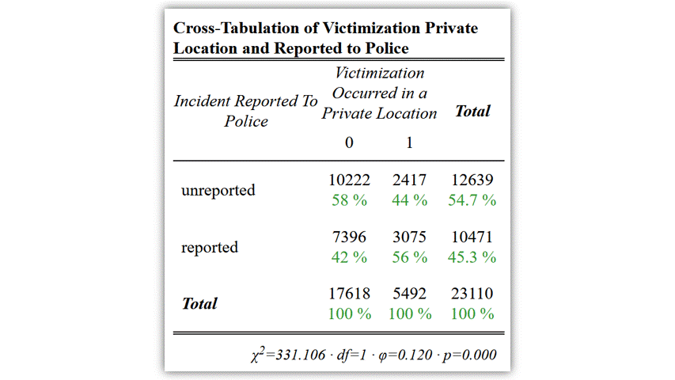

Comparing column percentage differences

So, if these column percentages differ, which they did (58% - 44% = 14 percentage point difference), then we can conclude there is an association between these variables in our sample. But how strong is that association? Or, if we have a probability sample, then can we confidently conclude that there is an association in the population, or the observed difference likely to be due to sampling variation instead?

In Assignment 6, we did not discuss in detail the note line below the table; let’s identify what is reported there. First, the note line reports results of a chi-squared test of independence, including the chi-squared test statistic ($\chi^2=331.106, df=1$) and later the *p*-value ($p=0.000$) associated with this test. This test assesses how likely it would be to observe differences in percentages within DV values (rows) and across IV values (columns) that are as at least as large as those observed if the two variables were truly “independent” or unrelated in the population. Additionally, the note line reports the phi-coefficient ($\phi=0.120$). As explained in this week’s book chapter, the phi-coefficient is a measure of association that helps us summarize the strength of relationship between two variables.

In this assignment, you will learn how to calculate and interpret a chi-squared test of independence in R. First, though, we want to walk you through the step-by-step (definitional) calculation of the chi-squared statistic. Our goal is to help you understand the logic underlying the chi-squared test of independence and, specifically, the null hypothesis of statistical independence between variables.

#### Illustrating statistical independence

As noted above, the chi-squared test of independence estimates the probability of observing column percentage differences as large or larger than those observed under the assumption - that is, given the null hypothesis - that the two variables are independent in the population.

What does “independent” mean in this context? Well, it means that we are comparing the **observed** cell frequencies in our crosstab with the **expected** cell frequencies under the null hypothesis, or with the cell frequencies that we would expect to see if the column and row marginal totals (i.e., univariate frequency distributions) remained the same yet there was no association ($\phi=0$) between the two variables.

As such, no discrepancy between observed cell frequencies and expected (null) cell frequencies will result in a chi-squared value of “0”. In contrast, large discrepancies between observed and expected cell frequencies (and/or large sample sizes) result in large chi-squared test statistics, smaller *p*-values, and more confidence in the inference that the observed differences would be highly improbable if the null hypothesis of statistical independence were true in the population.

To help you better understand the null hypothesis of independence, we will calculate the expected frequencies under the null for each cell in the example table above. As your book explains, the expected frequencies are the joint cell frequencies we would expect to see if the variables were independent or completely unrelated.

Before we calculate these expected frequencies, let’s start by reproducing the example table with only the marginal totals included (i.e., univariate frequency distributions); in the cells where we need to calculate expected frequencies, we will start by listing them as missing or “NA” values. We will manually build this table by inputting each frequency value row-by-row into a tibble (i.e., tidy data object) using the tidyverse `tibble::tribble()` function.

```r
expectedfreqs <- tribble(
  ~DV, ~non_private, ~private, ~Total,
  "unreported", NA, NA, 12639,
  "reported", NA, NA, 10471,
  "Total", 17618, 5492, 23110
  )
expectedfreqs %>%
  gt() %>%
   tab_header(title = md("Marginal Frequencies Only"))
```

Marginal Frequencies Only

| DV | non_private | private | Total |
| --- | --- | --- | --- |
| unreported | NA | NA | 12639 |
| reported | NA | NA | 10471 |
| Total | 17618 | 5492 | 23110 |

Now, let’s fill in the expected frequency values. Remember, these are the cell frequencies that we would expect to find if the variables were independent - that is, if there were absolutely no association between the two variables. To calculate each expected frequency, we multiply the cell’s row frequency total by the cell’s column frequency total and then divide by the total sample size (N). For example, the expected frequency for the top left cell is calculated as: ($E_{[1,1]}=\frac{12,639 * 17,618}{23,110}$.

*Note:* We formatted the expected frequencies to display only two decimals by using the `round()` function. However, when we added these values to our tibble, the `tribble()` function automatically made our formatting consistent by adding two decimals to the column marginals as well. So, we also applied a simple fix by modifying our `gt()` table with `fmt_number()` to remove the decimals in the column marginal frequencies (columns 2 & 3, row 3).

```r
EC1R1 <- round((12639*17618)/23110, digits=2)
EC1R2 <- round((10471*17618)/23110, digits=2)
EC2R1 <- round((12639*5492)/23110, digits=2)
EC2R2 <- round((10471*5492)/23110, digits=2)

expectedfreqs <- tribble(
  ~DV,          ~non_private, ~private, ~Total,
  "unreported", EC1R1,        EC2R1,    12639,
  "reported",   EC1R2,        EC2R2,    10471,
  "Total",      17618,        5492,     23110
  )
expectedfreqs %>%
  gt() %>%
   tab_header(title = md("Expected Frequencies")) %>%
   fmt_number(
    columns = 2:3,
    rows = 3,
    decimals = 0
    )
```

Expected Frequencies

| DV | non_private | private | Total |
| --- | --- | --- | --- |
| unreported | 9635.39 | 3003.61 | 12639 |
| reported | 7982.61 | 2488.39 | 10471 |
| Total | 17,618 | 5,492 | 23110 |

Before calculating chi-square, let’s first transform these expected frequencies into expected column percentages to help us interpret our (relative) frequency expectations under the null hypothesis of independence.

```r
EC1R1p <- round((((12639*17618)/23110)/17618), digits=4)
EC1R2p <- round((((10471*17618)/23110)/17618), digits=4)
EC2R1p <- round((((12639*5492)/23110)/5492), digits=4)
EC2R2p <- round((((10471*5492)/23110)/5492), digits=4)
expectedfreqs <- tribble(
  ~DV,          ~non_private, ~private, ~Total,
  "unreported", EC1R1p,        EC2R1p,    12639,
  "reported",   EC1R2p,        EC2R2p,    10471,
  "Total",      17618,        5492,     23110
  )
expectedfreqs %>%
  gt() %>%
   tab_header(title=md("Expected Column Percents")) %>%
   fmt_number(
    columns = 2:3,
    rows = 3,
    decimals = 0
    ) %>%
   fmt_percent(
    columns = 2:3,
    rows = 1:2,
    decimals = 1
    )
```

Expected Column Percents

| DV | non_private | private | Total |
| --- | --- | --- | --- |
| unreported | 54.7% | 54.7% | 12639 |
| reported | 45.3% | 45.3% | 10471 |
| Total | 17,618 | 5,492 | 23110 |

So, if the null hypothesis of independence (i.e., no association) were true, then we would expect about 45% of victimization incidents to be reported to police *irrespective* of whether the incident occurred in a private or a non-private location.

In contrast to these expectations under independence, we observed that about 56% of victimizations occurring in private locations were reported to police, whereas about 42% of victimizations occurring in non-private places were reported to police. Therefore, our observed frequencies differ from the expected frequencies under the null.

To test the null hypothesis of independence, we calculate a test statistic that essentially equals the sum of standardized differences between observed and expected cell frequencies in a crosstab. Specifically, the definitional formula for calculating the chi-squared test statistic is: $\chi^2_{obt}=\Sigma{\frac{(Obs-Exp)^2}{Exp}}$, or the sum of squared differences between observed and expected cell frequencies divided by expected frequencies. Below, we calculate each of the standardized differences for each cell and place them in our four table cells instead.

```r
stdiffC1R1 <- round(((10222 - EC1R1)^2)/EC1R1, digits=2)
stdiffC1R2 <- round(((7396 - EC1R2)^2)/EC1R2, digits=2)
stdiffC2R1 <- round(((2417 - EC2R1)^2)/EC2R1, digits=2)
stdiffC2R2 <- round(((3075 - EC2R2)^2)/EC2R2, digits=2)

expectedfreqs <- tribble(
  ~DV,          ~non_private, ~private, ~Total,
  "unreported", stdiffC1R1,        stdiffC2R1,    12639,
  "reported",   stdiffC1R2,        stdiffC2R2,    10471,
  "Total",      17618,        5492,     23110
  )
expectedfreqs %>%
  gt() %>%
   tab_header(title=md("Standardized differences in cell frequencies")) %>%
   fmt_number(
    columns = 2:3,
    rows = 3,
    decimals = 0
    )
```

Standardized differences in cell frequencies

| DV | non_private | private | Total |
| --- | --- | --- | --- |
| unreported | 35.71 | 114.57 | 12639 |
| reported | 43.11 | 138.29 | 10471 |
| Total | 17,618 | 5,492 | 23110 |

Our chi-squared test statistic, then, equals the sum of these four cell values:

```r
chisqtest <- stdiffC1R1 + stdiffC1R2 + stdiffC2R1 + stdiffC2R2
chisqtest
```

```
## [1] 331.68
```

```r
stdiffC1R1 <- round(((abs(10222 - EC1R1) -.5)^2)/EC1R1, digits=3)
stdiffC1R2 <- round(((abs(7396 - EC1R2) -.5)^2)/EC1R2, digits=3)
stdiffC2R1 <- round(((abs(2417 - EC2R1) -.5)^2)/EC2R1, digits=3)
stdiffC2R2 <- round(((abs(3075 - EC2R2) -.5)^2)/EC2R2, digits=3)

chisqtest_adj <- stdiffC1R1 + stdiffC1R2 + stdiffC2R1 + stdiffC2R2
chisqtest_adj
```

```
## [1] 331.108
```

Now that you know how to calculate the chi-squared test statistic, what do we do with it? You do the same thing we have done with other test statistics (e.g., *t* and *z*) - you compare it to a pre-specified critical value associated with an alpha level and a probability distribution of standardized values!

In this case, our test statistic (chi-squared or $\chi^2$) follows a chi-squared probability distribution. Like the *t* distribution, there are different chi-squared distributions that vary depending on the degrees of freedom associated with the test. In a chi-squared test of independence applied to a crosstab, we calculate degrees of freedom as equal to: (the number of rows minus 1) times (the number of columns minus one), or $df=(Rows-1)(Cols-1)$.

Below, we use [ggplot to visualize the chi-squared probability distribution](https://www.geo.fu-berlin.de/en/v/soga/Basics-of-statistics/Continous-Random-Variables/Chi-Square-Distribution/Chi-Square-Distribution-in-R/index.html) for a 2X2 table with *df*=(2-1)(2-1)=1.

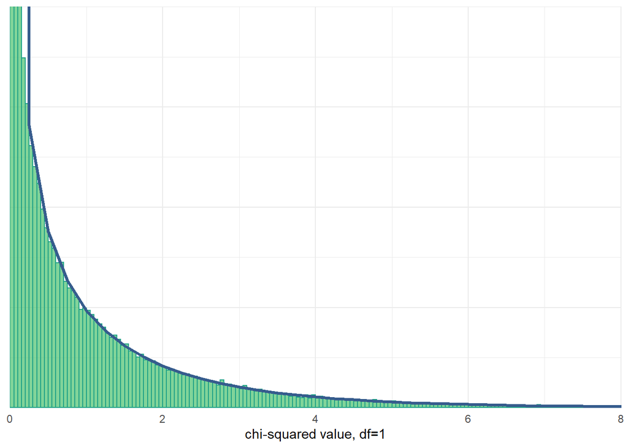

```r
x <- as.tibble(rchisq(100000, df = 1)) %>%
  mutate(
    critvals = if_else(value>3.84, "1", "0")
  )

x %>% ggplot() +
  geom_histogram(aes(x=value, y=..density..),
                 color="#1fa187", fill="#4ac16d", alpha=.7,
                 position="identity", breaks = seq(0, 10, by = .05)) +
  stat_function(fun = dchisq, args = list(df = 1),
                                color='#365c8d', size=1.1) +
  coord_cartesian(expand = FALSE, xlim=c(0,8), ylim=c(0,1)) +
  theme_minimal() +
  theme(axis.text.y=element_blank(),
        axis.ticks.y=element_blank()
        ) +
  labs(x="chi-squared value, df=1", y=NULL)
```

Now, let’s modify this graph a bit. First, we will overlay a vertical line at 3.841, which is the critical value for a chi-squared test with *df*=1 and alpha=0.05 ($\chi^2_{crit}=3.841$). Second, we will shade the distribution beyond our critical value with a different color and fill combination.

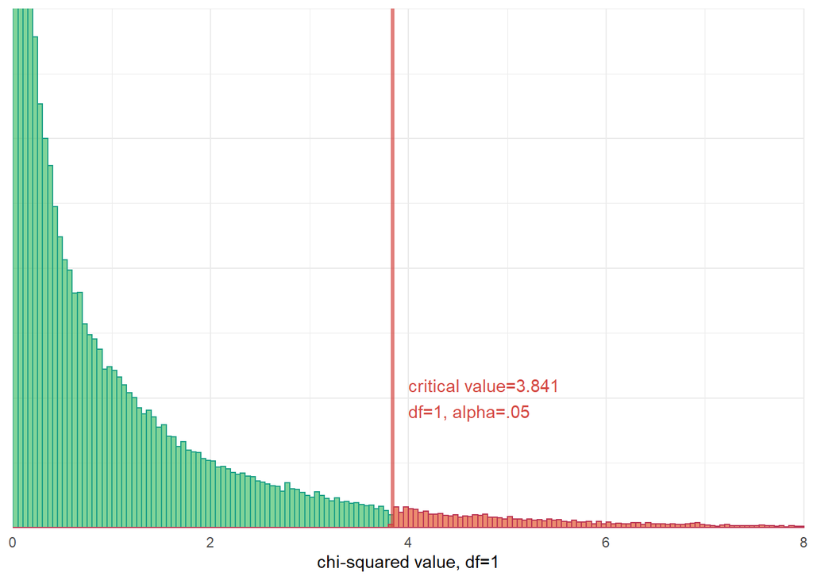

```r
x %>% ggplot(aes(x=value)) +
  geom_histogram(aes(y=..count.., color=critvals, fill=critvals),
                 alpha=.7,
                 position="identity", breaks = seq(0, 10, by = .05)) +
  coord_cartesian(expand = FALSE, xlim=c(0,8), ylim=c(0,4000)) +
  geom_vline(xintercept = 3.841, color = "#d44842", size=1.2, alpha=0.7) +
  annotate("text", x=4, y=1000, angle=0, color="#d44842", hjust=0,
           label="critical value=3.841\ndf=1, alpha=.05") +
  scale_color_manual(values=c("#1fa187","#bc3754")) +
  scale_fill_manual(values=c("#4ac16d","#e45a31")) +
  theme_minimal() +
  theme(axis.text.y=element_blank(),
        axis.ticks.y=element_blank(),
        legend.position="none"
        ) +
  labs(x="chi-squared value, df=1", y=NULL)
```

As with other null hypothesis tests you have learned about thus far, if our chi-squared test statistic is greater than the pre-specified critical value, we reject the null hypothesis of statistical independence. In contrast, if our test statistic is smaller than the critical value, we would fail to reject the null hypothesis of statistical independence.

So, where does our test statistic fall in the chi-squared distribution and in relation to the critical value? Let’s add a dashed line to our plot at the unadjusted value of $\chi^2_{obt}=331.68$ and see where it falls in the distribution. To see it, we will need to zoom out the plot’s x-axis quite a bit (from `xlim(0,8)` to `xlim(0,332)`). We will leave the y-axis limit the same as above to get a better sense of how far away our test statistic is from the critical value.

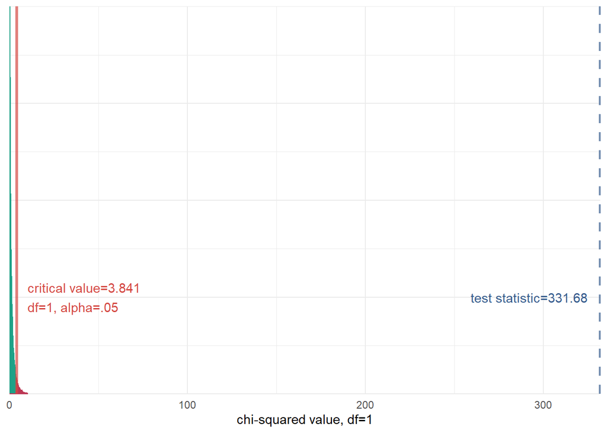

```r
x %>% ggplot(aes(x=value)) +
  geom_histogram(aes(y=..count.., color=critvals, fill=critvals),
                 alpha=.7,
                 position="identity", breaks = seq(0, 10, by = .05)) +
  coord_cartesian(expand = FALSE, xlim=c(0,332), ylim=c(0,4000)) +
  geom_vline(xintercept = 3.841, color = "#d44842", size=1.2, alpha=0.7) +
  annotate("text", x=10, y=1000, angle=0, color="#d44842", hjust=0,
           label="critical value=3.841\ndf=1, alpha=.05") +
  geom_vline(xintercept = 331.68, color = "#365c8d", linetype="dashed",
             size=1, alpha=0.7) +
  annotate("text", x=325, y=1000, angle=0, color="#365c8d", hjust=1,
           label="test statistic=331.68") +
  scale_color_manual(values=c("#1fa187","#bc3754")) +
  scale_fill_manual(values=c("#4ac16d","#e45a31")) +
  theme_minimal() +
  theme(axis.text.y=element_blank(),
        axis.ticks.y=element_blank(),
        legend.position="none"
        ) +
  labs(x="chi-squared value, df=1", y=NULL)
```

As you can see in the plot above, the chi-squared test statistic is greater than critical value (331.68 > 3.841), so there is sufficient evidence to reject the null hypothesis of statistical independence. This is also implied by the *p*-value, which is less than the alpha level (0.000 < 0.05). If the null hypothesis indeed were true in the population, then it would be highly improbable to obtain a sample with differences at least as large as those observed in the original table due to sampling variability alone. Therefore, based on these sample statistics, we can infer that the null hypothesis of independence is unlikely to be true in the population.

### Part 1 (Assignment 9.1)

#### Goal: Filter data for violent incidents (injured==1) and examine univariate frequency distributions

For this assignment, you will learn to conduct chi-squared tests of independence in R by working through Question #5 from Chapter 9 SPSS Exercises in the book. That question asks you to investigate whether women are more likely than men to experience violent victimization by strangers. To do so, you first need to filter the data to include only victimizations that resulted in injury to the victim (with the ‘injured’ variable), then conduct a chi-squared test of independence on the variables ‘V3018’ (sex of victim) and ‘Relationship’ (relationship between victim and offender) to test the hypothesis that the two variables are statistically independent.

Below, we will demonstrate how to complete the assignment steps by investigating a different question using the same data: *Are violent victimizations that occur in private locations more or less likely to be reported to police than violent victimizations that do not occur in private locations?* This is nearly the same question that we investigated with sample descriptive statistics (crosstabs) in Assignment 6 and portrayed in the example above. One important difference, however, is that we will be filtering our data to keep only those victimizations where an injury occurred so that we can examine violent victimizations rather than all (violent and nonviolent) criminal victimizations. As before, we will use the ‘privatelocation’ and ‘reportedtopolice’ variables from the NCVS data, then we will generate a crosstab and conduct a hypothesis test to make a population inference about the (non)independence of these two variables.

- Recall, these NCVS data contain survey responses about individuals’ experiences with criminal victimation collected from nationally representative samples of people in U.S. households. This particular subset contains data from the 1992 to 2013 NCVS studies and only includes data from respondents who reported either violent or nonviolent assault by a single offender. For more information, see Bachman, Paternoster, & Wilson’s book.
  - ‘privatelocation’ is a dummy variable (i.e., 0 or 1 values) indicating whether the reported victimization occurred in a private location (0=Not a private location; 1=Private location).
  - ‘reportedtopolice’ is a dummy variable indicating whether the victimization incident was reported to the police (0=Unreported; 1=Reported).
  - Remember, too, that you can check these details using `sjplot::view_df()` (e.g., by typing `NCVSData %>% view_df()`).

By illustrating the process with different variables, you will get the experience of conducting these tests in R yourself using the same data. Then, after working through the process with our example, you will repeat the same steps with the ‘V3018’ (sex of victim) and ‘Relationship’ variables afterwards using the same filtered data to complete the assignment. **Be sure to repeat these steps with the correct variables and filtered data listed in the assignment to ensure you receive full credit.**

*(**Note:* *Remember that, when following instructions, always substitute “LastName” for your own last name and substitute YEAR_MO_DY for the actual date. E.g., **2022_07_06_Fordham_K300Assign9**)*

1. Go to your K300_L folder, which should contain the R Markdown file you created for Assignment 8 (named **YEAR_MO_DY_LastName_K300Assign8**). Click to open the R Markdown file.
   1. Remember, we open RStudio in this way so the `here` package will automatically set our K300_L folder as the top-level directory.
   2. In RStudio, open a new R Markdown document. If you do not recall how to do this, refer to Assignment 1.
   3. The dialogue box asks for a **Title**, an **Author**, and a **Default Output Format** for your new R Markdown file.
   4. In the **Title** box, enter *K300 Assignment 9*.
   5. In the **Author** box, enter your First and Last Name (e.g., *Tyeisha Fordham*).
   6. Under **Default Output Format** box, select “HTML document” (HTML is usually the default selection)
2. Remember that the new R Markdown file contains a simple pre-populated template to show users how to do basic tasks like add settings, create text headings and text, insert R code chunks, and create plots. Be sure to delete this text before you begin working.
   1. Create a second-level header titled: “Part 1 (Assignment 9.1).” Then, create a third-level header titled: “Read in and Filter NCVS Data”
   2. This assignment must be completed by the student and the student alone. To confirm that this is your work, please begin all assignments with this text: This R Markdown document contains *my work* for Assignment 9. It is **my work** and *only* my work.
   3. Now, you need to get data into RStudio. You already know how to do this, but please refer to Assignment 1 if you have questions.
3. Create a third-level header in R Markdown (hereafter, “RMD”) file titled: “Load Libraries”
   1. Insert an R chunk.
   2. Inside the new R code chunk, load the following packages: `tidyverse`, `haven`, `here`, `sjmisc`, `sjPlot`, and `gt`. Recall, you only need to install packages one time. However, you must load them each time you start a new R session.
4. After your first code chunk, create another third-level header in RMD titled: “Read Data into R”
   1. Insert another R code chunk.
   2. In the new R code chunk, read and assign the “NCVSLoneOffenderAssaults1992to2013.sav” SPSS datafile into R. Assign the data to an object named `NCVSData`.
      - Forget how to do this? Refer to any of the previous assignments.
   3. In the same code chunk, on a new line below your read data/save object command, type the name of your new R data object: `NCVSData`.
      - This will call the object and provide a brief view of the data. Remember, you can get a similar but more visually appealing view by simply clicking on the object in the “Environment” window. Also, be sure to put these functions on separate lines or they will not run properly.
      - Here is a glimpse of what the first few rows of your data should look like:

```r
NCVSData <- read_spss(here("Datasets", "NCVSLoneOffenderAssaults1992to2013.sav"))

head(NCVSData) %>% gt()
```

| YEAR | V2119 | V2129 | V3014 | V3016 | V3018 | V3021 | V3023 | V3023A | V3024 | V2026 | V4049 | V4234 | V4235 | V4236 | V4237 | V4237A | V4238 | V4239 | V4240 | V4241 | V4242 | V4243 | V4244 | V4245 | V4246 | V4246A | V4246B | V4246C | V4246E | … |
| --- | --- | --- | --- | --- | --- | --- | --- | --- | --- | --- | --- | --- | --- | --- | --- | --- | --- | --- | --- | --- | --- | --- | --- | --- | --- | --- | --- | --- | --- | --- |
| 2000 | 2 | 2 | 34 | 6 | 1 | 1 | 1 | NA | 2 | 12 | 1 | 1 | NA | 2 | 6 | NA | 2 | 3 | NA | 1 | NA | 3 | NA | 1 | 1 | NA | NA | NA | NA | … |
| 2000 | 2 | 1 | 51 | 3 | 1 | 2 | 2 | NA | 2 | 10 | 1 | 1 | NA | 1 | 6 | NA | 2 | 1 | 1 | 1 | NA | 3 | NA | NA | 2 | NA | NA | NA | NA | … |
| 2000 | 2 | 2 | 20 | 5 | 1 | 1 | 1 | NA | 2 | 14 | 2 | 1 | NA | 1 | 5 | NA | 2 | 1 | 1 | 1 | NA | 3 | NA | NA | 3 | NA | NA | NA | NA | … |
| 2000 | 2 | 2 | 38 | 3 | 2 | 1 | 1 | NA | 2 | 10 | 2 | 1 | NA | 1 | 6 | NA | 2 | 2 | NA | 1 | NA | 3 | NA | 2 | 1 | NA | NA | NA | NA | … |
| 2000 | 2 | 1 | 71 | 1 | 2 | 1 | 1 | NA | 2 | 10 | 2 | 1 | NA | 2 | 6 | NA | 2 | 2 | NA | 1 | NA | 2 | NA | NA | 2 | NA | NA | NA | NA | … |
| 2000 | 2 | 2 | 12 | 5 | 1 | 1 | 1 | NA | 2 | 10 | 2 | 1 | NA | 1 | 2 | NA | 3 | 3 | NA | 1 | NA | 2 | NA | NA | 1 | NA | NA | NA | NA | … |

5. Next, the assignment question asks you to select only those cases where the victim was injured by the offender. Recall, we can use `dplyr::filter()` to select certain rows of data based on column values. a. Create a third-level header titled: “Selecting Cases Where Victim was Injured”. Then, insert an R chunk. b. Type `NCVSData_inj <- NCVSData %>%`. Hit enter and type `dplyr::filter(injured == 1)`. c. Next, hit enter and type `NCVSData_inj %>% frq(injured)` to view the frequency distribution for the “injured” variable and ensure our new data object contains only those cases where the victim sustained injuries during victimization (`injured == 1`). In the frequency table for the “injured” variable, the row labeled “uninjured” (value = “0”) should have an N=0.

```r
#Selecting only those observations (rows) where the offender was a male. 'maleoff' = 1 if the offender was male and 'maleoff' = 0 if the offender was female. If 'maleoff' = 0, it is excluded.
NCVSData_inj <- NCVSData %>%
  dplyr::filter(injured == 1)
```

```r
NCVSData_inj %>%
  frq(injured)
```

```
## Victim Sustained Injuries During Vicitmization (injured) <numeric>
## # total N=7809 valid N=7809 mean=1.00 sd=0.00
##
## Value |     Label |    N | Raw % | Valid % | Cum. %
## ---------------------------------------------------
##     0 | uninjured |    0 |     0 |       0 |      0
##     1 |   injured | 7809 |   100 |     100 |    100
##  <NA> |      <NA> |    0 |     0 |    <NA> |   <NA>
```

```r
NCVSData_inj %>%
  frq(privatelocation)
```

```
## Victimization Occurred in a Private Location (privatelocation) <numeric>
## # total N=7809 valid N=7809 mean=0.39 sd=0.49
##
## Value |    N | Raw % | Valid % | Cum. %
## ---------------------------------------
##     0 | 4741 | 60.71 |   60.71 |  60.71
##     1 | 3068 | 39.29 |   39.29 | 100.00
##  <NA> |    0 |  0.00 |    <NA> |   <NA>
```

```r
NCVSData_inj %>%
  frq(reportedtopolice)
```

```
## Incident Reported To Police (reportedtopolice) <numeric>
## # total N=7809 valid N=7590 mean=0.56 sd=0.50
##
## Value |      Label |    N | Raw % | Valid % | Cum. %
## ----------------------------------------------------
##     0 | unreported | 3308 | 42.36 |   43.58 |  43.58
##     1 |   reported | 4282 | 54.83 |   56.42 | 100.00
##  <NA> |       <NA> |  219 |  2.80 |    <NA> |   <NA>
```

### Part 2 (Assignment 9.2)

#### Goal: Generate crosstab and conduct chi-squared test of independence

Now we will generate a crosstab and conduct a chi-square test statistic using R. Additionally, we will calculate a Cramer’s V coefficient to help describe the strength of the relationship between victimization location and reporting to police. Recall, you will then repeat these steps to generate a cross-tab of the variables ‘relationship’ and ‘V3018’ (victim sex) to answer the book’s question #5 and related questions in Quiz 9.

```r
NCVSData_inj %>%
  select(reportedtopolice, privatelocation) %>% #list row (DV) first then col (IV) last - can have multiple IVs
  sjtab(title = "Crosstab of Incident Location and Victim Reporting",
        show.col.prc = TRUE,
        statistics = "cramer",
        use.viewer = TRUE)
```

Crosstab of Incident Location and Victim Reporting

[output not shown]

```r
#note to students to look in viewer pane like they did for sjplot view_df function. the tidy output should show in knitted file!

# Want to save html table as image instead?
# Add `file = here("Images", "mytable.html")` to sjtab() code above
# library(webshot)
# webshot::install_phantomjs() # run if first time loading webshot package
# webshot(here("Images", "mytable.html"), here("Images", "mytable.png"))
# knitr::include_graphics(here("Images", "mytable.png"))
```

```r
# Run a chi-square test using base R
chisq <- chisq.test(NCVSData_inj$reportedtopolice, NCVSData_inj$privatelocation)
chisq
```

```
##
##  Pearson's Chi-squared test with Yates' continuity correction
##
## data:  NCVSData_inj$reportedtopolice and NCVSData_inj$privatelocation
## X-squared = 70.529, df = 1, p-value < 2.2e-16
```

7. We can also explore our results from the base R `chisq.test()` to identify the observed and expected frequency values that were used to calculate the chi-square test statistic. From these values, you could easily calculate the chi-square test statistic by hand. To do this, insert a new R chunk and simply call the new data object, `chisq` and type `$observed` or `$expected` immediately after it.
- Here are the observed frequencies, which we generated with `chisq$observed`:

```r
#Determine observed frequencies
chisq$observed
```

```
##                              NCVSData_inj$privatelocation
## NCVSData_inj$reportedtopolice    0    1
##                             0 2169 1139
##                             1 2399 1883
```

- In comparison, here are the expected frequencies, which we generated with `chisq$expected`:

```r
#Determine expected frequencies
chisq$expected
```

```
##                              NCVSData_inj$privatelocation
## NCVSData_inj$reportedtopolice        0        1
##                             0 1990.902 1317.098
##                             1 2577.098 1704.902
```

### Assignment 9 Objective Checks

#### After completing assignment #9…

- do you recognize you can manually build a simple tibble row-by-row using tidyverse’s `tibble::tribble()`?
- do you recognize you can use `round()` to specify number of decimals on numeric values?
- do you recognize you can modify a `gt()` table to add or remove the decimals in specific columns or rows with `fmt_number()`?
- are you able to conduct a chi-squared test of independence using `sjPlot::sjtab()` or `chisq.test()` and interpret results?
  - do you know how to specify different measures of association with `statistics=` using `sjPlot::sjtab()` and interpret them appropriately?
  - do you know how to generate observed and expected frequencies by assigning results of `chisq.test()` to an object (e.g., `chisq`) and then calling elements from object (e.g., `chisq$observed` or `chisq$expected`)?